# Research Question 2: Can ESCS be modelled differently using IRT?

#### 1PL IRT model using all items on country level

```r
# run 1PL and estimate coefficients
parms_1PL <- dexterMML::fit_1pl(responses)
coef(parms_1PL)
```

```
## # A tibble: 4,361 × 4
##    item_id        item_score     beta SE_beta
##    <chr>               <int>    <dbl>   <dbl>
##  1 ST005Q01TA_ALB          3 -2.74     0.0820
##  2 ST005Q01TA_ALB          4 -0.00299  0.0286
##  3 ST005Q01TA_ARE          3 -1.42     0.0187
##  4 ST005Q01TA_ARE          4 -1.33     0.0192
##  5 ST005Q01TA_ARG          3 -1.25     0.0199
##  6 ST005Q01TA_ARG          4 -1.21     0.0245
##  7 ST005Q01TA_AUS          3 -1.95     0.0373
##  8 ST005Q01TA_AUS          4 -1.25     0.0228
##  9 ST005Q01TA_AUT          3 -1.96     0.0409
## 10 ST005Q01TA_AUT          4  0.282    0.0280
## # ℹ 4,351 more rows
```

```r
# calculate theta: the ability estimate
theta_1PL <- dexterMML::ability.mml(responses, parms_1PL, method = "WLE")
ESCS_items_long_complete <- ESCS_items_long_complete %>%
  mutate(person_id = as.character(person_id))
theta_1PL <- theta_1PL %>%
  inner_join(ESCS_items_long_complete)
# correlations ESCS and cognitive variables
cor(theta_1PL$theta, theta_1PL$MATH, use = "pairwise.complete.obs") # new ESCS
```

```
## [1] 0.2786111
```

```r
cor(data$ESCS, data$MATH, use = "pairwise.complete.obs") # PISA ESCS
```

```
## [1] 0.4407447
```

```r
cor(theta_1PL$theta, theta_1PL$READ, use = "pairwise.complete.obs") # new ESCS
```

```
## [1] 0.2610158
```

```r
cor(data$ESCS, data$READ, use = "pairwise.complete.obs") # PISA ESCS
```

```
## [1] 0.4093611
```

```r
cor(theta_1PL$theta, theta_1PL$SCIE, use = "pairwise.complete.obs") # new ESCS
```

```
## [1] 0.2677972
```

```r
cor(data$ESCS, data$SCIE, use = "pairwise.complete.obs") # PISA ESCS
```

```
## [1] 0.4152918
```

```r
# correlation of new ESCS is always lower then the correlation of the PISA ESCS
```

### 2. All countries together

#### 2PL IRT model taking all countries together

```r
# take the dataset used for the 2PL taking all countries separately
ESCS_items_long_complete2 <- ESCS_items_long_complete

# make sure item_id does not include country anymore
ESCS_items_long_complete2$item_id <- ESCS_items_long_complete2$item

# select only the responses needed for the IRT model
responses2 <- ESCS_items_long_complete2 %>% dplyr::select(person_id, item_id, item_score, CNT)

# fit 2PL model
parms_2PL_2 <- dexterMML::fit_2pl(responses2)
coef <- coef(parms_2PL_2)

# No warnings: the model is more robust
# No items need to be excluded from the model

# calculate theta: the ability estimate
theta_2PL_2 <- dexterMML::ability.mml(responses2, parms_2PL_2, method = "WLE")
# still a warning when guessing ability
ESCS_items_long_complete2 <- ESCS_items_long_complete2 %>%
  mutate(person_id = as.character(person_id))
theta_2PL_2 <- theta_2PL_2 %>%
  inner_join(ESCS_items_long_complete2)
# convert to wide format
theta_wide_2 <- theta_2PL_2 %>% select(CNT, person_id, MATH, READ, SCIE, theta, se) %>%
  distinct(.keep_all = TRUE)

# correlations ESCS and cognitive variables
cor(theta_wide_2$theta, theta_wide_2$MATH, use = "pairwise.complete.obs") # new ESCS
```

```
## [1] 0.4059377
```

```r
cor(data$ESCS, data$MATH, use = "pairwise.complete.obs") # PISA ESCS
```

```
## [1] 0.4407447
```

```r
cor(theta_wide_2$theta, theta_wide_2$READ, use = "pairwise.complete.obs") # new ESCS
```

```
## [1] 0.3730609
```

```r
cor(data$ESCS, data$READ, use = "pairwise.complete.obs") # PISA ESCS
```

```
## [1] 0.4093611
```

```r
cor(theta_wide_2$theta, theta_wide_2$SCIE, use = "pairwise.complete.obs") # new ESCS
```

```
## [1] 0.3779025
```

```r
cor(data$ESCS, data$SCIE, use = "pairwise.complete.obs") # PISA ESCS
```

```
## [1] 0.4152918
```

```r
# the correlation using PISA's ESCS is still higher, but not as much
```

#### Plotting the betas of the 2PL

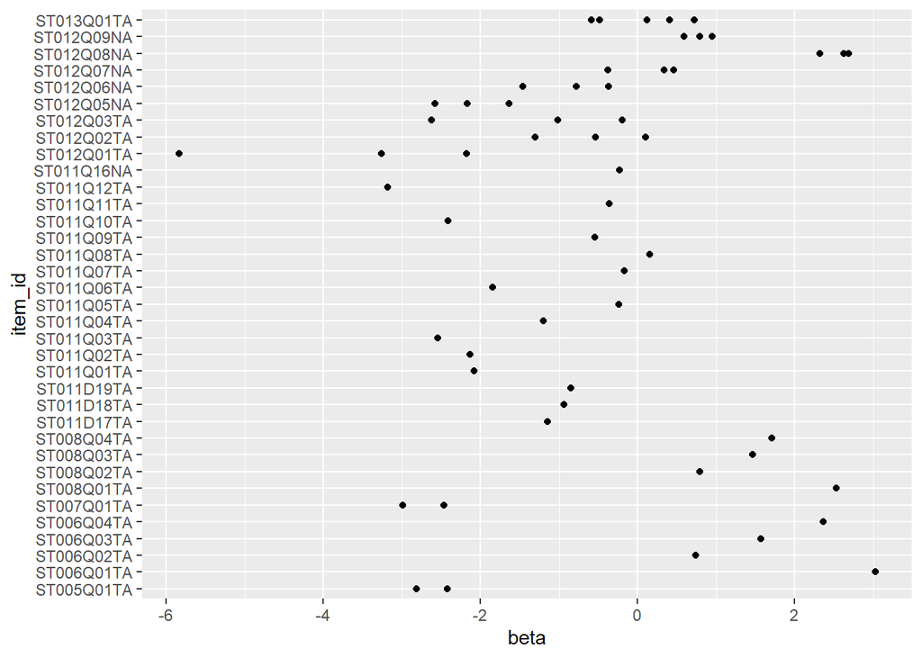

```r
# create dataset
data_2PL_2 <- coef(parms_2PL_2)

# plot betas per item
ggplot(data_2PL_2, aes(x=item_id, y=beta)) +
  geom_point() +
  coord_flip() +
  geom_errorbar(aes(ymin=beta-SE_beta, ymax=beta+SE_beta), width=.2,
                position=position_dodge(0.05))
```

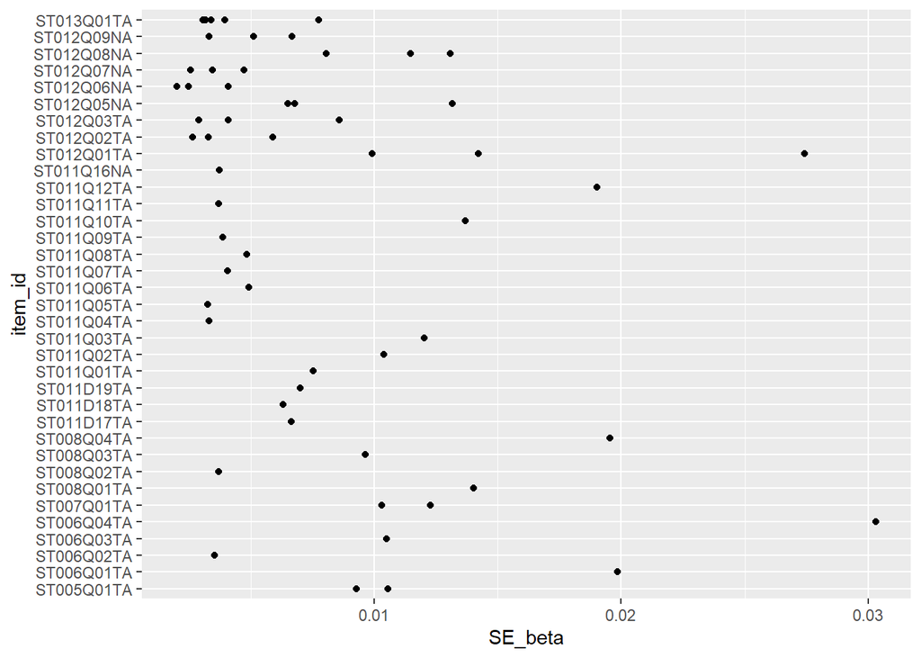

```r
ggplot(data_2PL_2, aes(x=item_id, y=SE_beta)) +
  geom_point() +
  coord_flip()
```

```r
# fit 1PL model
parms_1PL_2 <- dexterMML::fit_2pl(responses2)
coef(parms_1PL_2)
```

```
## # A tibble: 57 × 6
##    item_id    alpha item_score   beta SE_alpha SE_beta
##    <chr>      <dbl>      <int>  <dbl>    <dbl>   <dbl>
##  1 ST005Q01TA 0.403          3 -2.82   0.00215 0.0106
##  2 ST005Q01TA 0.403          4 -2.42   0.00215 0.00926
##  3 ST006Q01TA 0.806          1  3.02   0.00607 0.0199
##  4 ST006Q02TA 1.24           1  0.739  0.00513 0.00352
##  5 ST006Q03TA 0.609          1  1.56   0.00400 0.0105
##  6 ST006Q04TA 0.312          1  2.36   0.00385 0.0303
##  7 ST007Q01TA 0.372          3 -2.99   0.00208 0.0123
##  8 ST007Q01TA 0.372          4 -2.47   0.00208 0.0103
##  9 ST008Q01TA 0.949          1  2.53   0.00628 0.0140
## 10 ST008Q02TA 1.23           1  0.789  0.00521 0.00371
## # ℹ 47 more rows
```

```r
# No warnings: the model is more robust
# No items need to be excluded from the model

# calculate theta: the ability estimate
theta_1PL_2 <- dexterMML::ability.mml(responses2, parms_1PL_2, method = "WLE")
# still a warning when guessing ability
ESCS_items_long_complete2 <- ESCS_items_long_complete2 %>%
  mutate(person_id = as.character(person_id))
theta_1PL_2 <- theta_1PL_2 %>%
  inner_join(ESCS_items_long_complete2)
# convert to wide format
theta_wide_3 <- theta_1PL_2 %>% select(CNT, person_id, MATH, READ, SCIE, theta, se) %>%
  distinct(.keep_all = TRUE)

# correlations ESCS and cognitive variables
cor(theta_wide_3$theta, theta_wide_3$MATH, use = "pairwise.complete.obs") # new ESCS
```

```
## [1] 0.4059377
```

```r
cor(data$ESCS, data$MATH, use = "pairwise.complete.obs") # PISA ESCS
```

```
## [1] 0.4407447
```

```r
cor(theta_wide_3$theta, theta_wide_3$READ, use = "pairwise.complete.obs") # new ESCS
```

```
## [1] 0.3730609
```

```r
cor(data$ESCS, data$READ, use = "pairwise.complete.obs") # PISA ESCS
```

```
## [1] 0.4093611
```

```r
cor(theta_wide_3$theta, theta_wide_3$SCIE, use = "pairwise.complete.obs") # new ESCS
```

```
## [1] 0.3779025
```

```r
cor(data$ESCS, data$SCIE, use = "pairwise.complete.obs") # PISA ESCS
```

```
## [1] 0.4152918
```

```r
# the correlation using PISA's ESCS is still higher
```

#### Plotting the betas of the 1PL

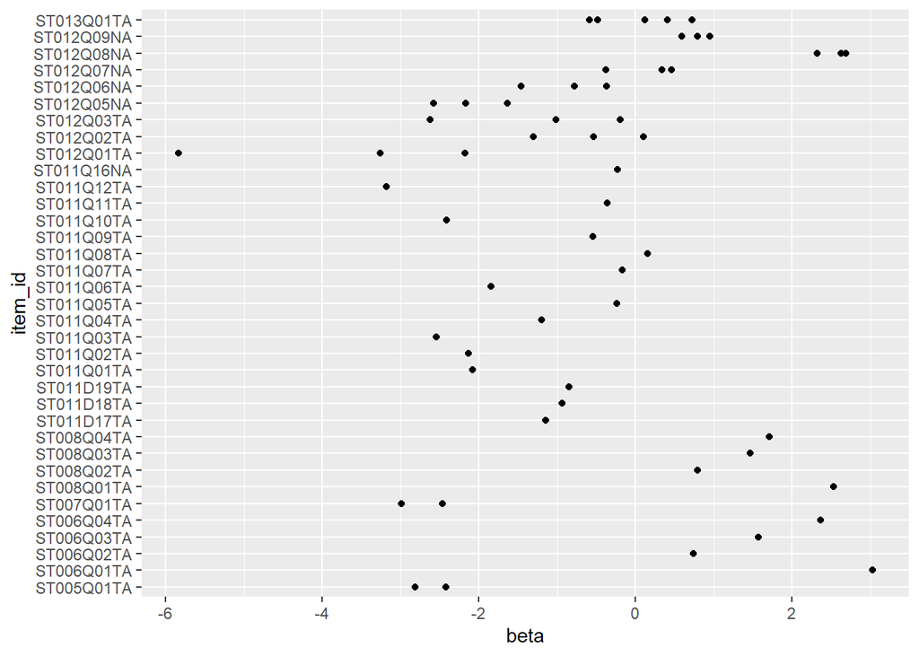

```r
# create dataset
data_1PL_2 <- coef(parms_1PL_2)

# plot betas per item
ggplot(data_1PL_2, aes(x=item_id, y=beta)) +
  geom_point() +
  coord_flip() +
  geom_errorbar(aes(ymin=beta-SE_beta, ymax=beta+SE_beta), width=.2,
                position=position_dodge(0.05))
```

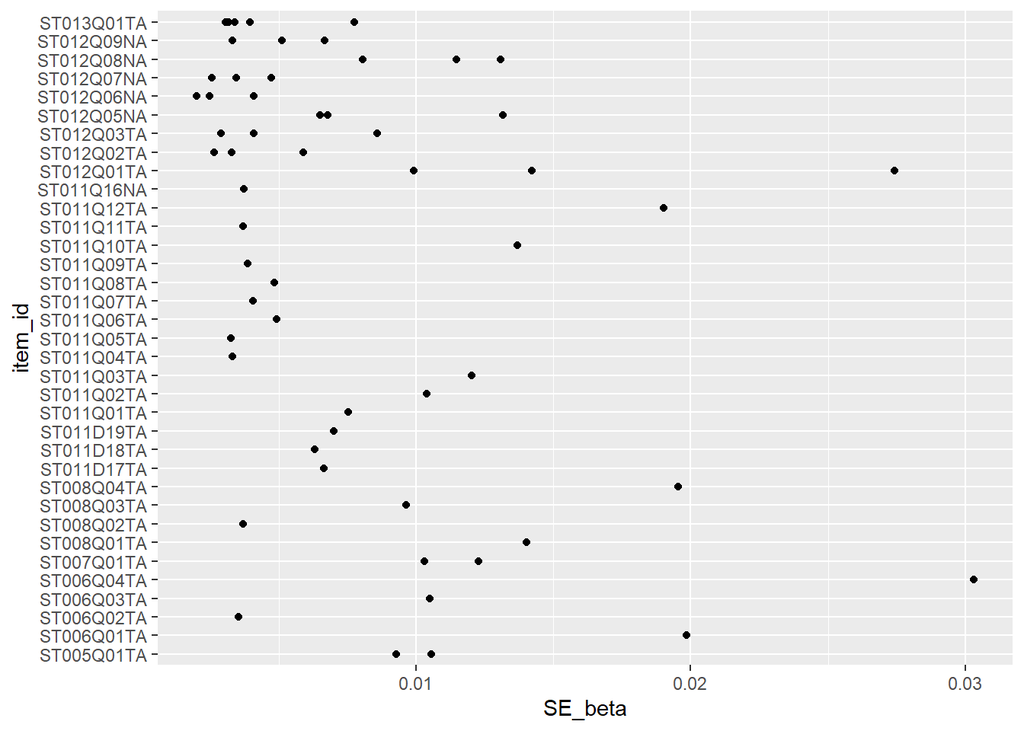

```r
ggplot(data_1PL_2, aes(x=item_id, y=SE_beta)) +
  geom_point() +
  coord_flip()
```

### Inspect occupational status parents

```r
# data$OCOD1 # ISCO-08 occupational code mother
# data$OCOD2 # ISCO-08 occupational code father
# data$BMMJ1 # ISEI of mother
# data$BFMJ2 # ISEI of father

# create dataframe with occupation and cognitive variables
data_occupation <- data %>% dplyr::select(MATH, READ, SCIE, BMMJ1, BFMJ2, HISEI)

# create variable for mean occupation value
data_occupation$MISEI <- data_occupation %>% dplyr::select(BMMJ1, BFMJ2) %>% cbind() %>%
  apply(1, mean)

# create variable for lowest occupation value
data_occupation$LISEI <- data_occupation %>% dplyr::select(BMMJ1, BFMJ2) %>% cbind() %>%
  apply(1, min)

# inspect correlation
cor(data_occupation, use = "pairwise.complete.obs")
```

```
##            MATH      READ      SCIE     BMMJ1     BFMJ2     HISEI     MISEI
## MATH  1.0000000 0.8811021 0.9135949 0.3345781 0.2840961 0.3410336 0.3759309
## READ  0.8811021 1.0000000 0.9241710 0.3180114 0.2710862 0.3245879 0.3594232
## SCIE  0.9135949 0.9241710 1.0000000 0.3224188 0.2758734 0.3296960 0.3641434
## BMMJ1 0.3345781 0.3180114 0.3224188 1.0000000 0.3814017 0.7809526 0.8447335
## BFMJ2 0.2840961 0.2710862 0.2758734 0.3814017 1.0000000 0.7876324 0.8169148
## HISEI 0.3410336 0.3245879 0.3296960 0.7809526 0.7876324 1.0000000 0.9229006
## MISEI 0.3759309 0.3594232 0.3641434 0.8447335 0.8169148 0.9229006 1.0000000
## LISEI 0.3514456 0.3363865 0.3415056 0.7828355 0.7103576 0.6622425 0.8996892
##           LISEI
## MATH  0.3514456
## READ  0.3363865
## SCIE  0.3415056
## BMMJ1 0.7828355
## BFMJ2 0.7103576
## HISEI 0.6622425
## MISEI 0.8996892
## LISEI 1.0000000
```

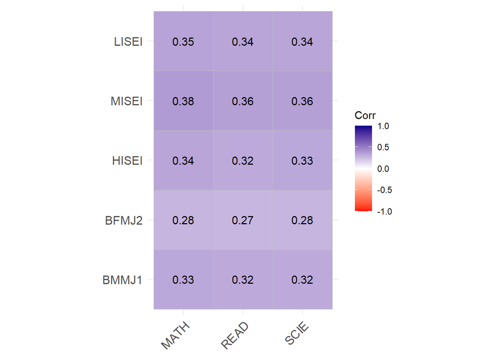

```r
# make into dataframe
data_cor <- cor(data_occupation, use = "pairwise.complete.obs")
data_cor <- as.data.frame(data_cor)
ggcorrplot(data_cor[1:3, 4:8], colors = c("red", "white", "darkblue"),
           lab = TRUE)
```

```r
# correlation between occupational status and the cognitive variables is highest
# if the mean occupational value is used

# regression models
summary(lm(data = data_occupation, MATH ~ BMMJ1)) # mother
```

```
##
## Call:
## lm(formula = MATH ~ BMMJ1, data = data_occupation)
##
## Residuals:
##     Min      1Q  Median      3Q     Max
## -413.54  -65.10   -0.68   64.48  359.25
##
## Coefficients:
##              Estimate Std. Error t value Pr(>|t|)
## (Intercept) 4.093e+02  2.570e-01  1592.4   <2e-16 ***
## BMMJ1       1.364e+00  5.318e-03   256.5   <2e-16 ***
## ---
## Signif. codes:  0 '***' 0.001 '**' 0.01 '*' 0.05 '.' 0.1 ' ' 1
##
## Residual standard error: 91.81 on 522082 degrees of freedom
##   (89920 observations deleted due to missingness)
## Multiple R-squared:  0.1119, Adjusted R-squared:  0.1119
## F-statistic: 6.581e+04 on 1 and 522082 DF,  p-value: < 2.2e-16
```

```r
summary(lm(data = data_occupation, MATH ~ BFMJ2)) # father
```

```
##
## Call:
## lm(formula = MATH ~ BFMJ2, data = data_occupation)
##
## Residuals:
##     Min      1Q  Median      3Q     Max
## -416.40  -66.74    0.15   66.94  355.78
##
## Coefficients:
##              Estimate Std. Error t value Pr(>|t|)
## (Intercept) 4.135e+02  2.953e-01  1400.4   <2e-16 ***
## BFMJ2       1.249e+00  5.988e-03   208.6   <2e-16 ***
## ---
## Signif. codes:  0 '***' 0.001 '**' 0.01 '*' 0.05 '.' 0.1 ' ' 1
##
## Residual standard error: 93.46 on 495809 degrees of freedom
##   (116193 observations deleted due to missingness)
## Multiple R-squared:  0.08071,    Adjusted R-squared:  0.08071
## F-statistic: 4.353e+04 on 1 and 495809 DF,  p-value: < 2.2e-16
```

```r
summary(lm(data = data_occupation, MATH ~ HISEI)) # highest
```

```
##
## Call:
## lm(formula = MATH ~ HISEI, data = data_occupation)
##
## Residuals:
##     Min      1Q  Median      3Q     Max
## -411.34  -64.70   -0.33   64.63  367.34
##
## Coefficients:
##              Estimate Std. Error t value Pr(>|t|)
## (Intercept) 3.915e+02  2.981e-01  1313.2   <2e-16 ***
## HISEI       1.456e+00  5.368e-03   271.2   <2e-16 ***
## ---
## Signif. codes:  0 '***' 0.001 '**' 0.01 '*' 0.05 '.' 0.1 ' ' 1
##
## Residual standard error: 91.73 on 558992 degrees of freedom
##   (53010 observations deleted due to missingness)
## Multiple R-squared:  0.1163, Adjusted R-squared:  0.1163
## F-statistic: 7.357e+04 on 1 and 558992 DF,  p-value: < 2.2e-16
```

```r
summary(lm(data = data_occupation, MATH ~ MISEI)) # mean
```

```
##
## Call:
## lm(formula = MATH ~ MISEI, data = data_occupation)
##
## Residuals:
##     Min      1Q  Median      3Q     Max
## -439.42  -63.23    0.03   63.39  356.22
##
## Coefficients:
##              Estimate Std. Error t value Pr(>|t|)
## (Intercept) 3.880e+02  3.282e-01  1182.1   <2e-16 ***
## MISEI       1.907e+00  6.938e-03   274.8   <2e-16 ***
## ---
## Signif. codes:  0 '***' 0.001 '**' 0.01 '*' 0.05 '.' 0.1 ' ' 1
##
## Residual standard error: 90.09 on 458899 degrees of freedom
##   (153103 observations deleted due to missingness)
## Multiple R-squared:  0.1413, Adjusted R-squared:  0.1413
## F-statistic: 7.553e+04 on 1 and 458899 DF,  p-value: < 2.2e-16
```

```r
summary(lm(data = data_occupation, MATH ~ LISEI)) # lowest
```

```
##
## Call:
## lm(formula = MATH ~ LISEI, data = data_occupation)
##
## Residuals:
##     Min      1Q  Median      3Q     Max
## -444.39  -64.40   -0.23   64.37  350.19
##
## Coefficients:
##              Estimate Std. Error t value Pr(>|t|)
## (Intercept) 4.121e+02  2.660e-01  1549.3   <2e-16 ***
## LISEI       1.731e+00  6.805e-03   254.3   <2e-16 ***
## ---
## Signif. codes:  0 '***' 0.001 '**' 0.01 '*' 0.05 '.' 0.1 ' ' 1
##
## Residual standard error: 91.02 on 458899 degrees of freedom
##   (153103 observations deleted due to missingness)
## Multiple R-squared:  0.1235, Adjusted R-squared:  0.1235
## F-statistic: 6.467e+04 on 1 and 458899 DF,  p-value: < 2.2e-16
```

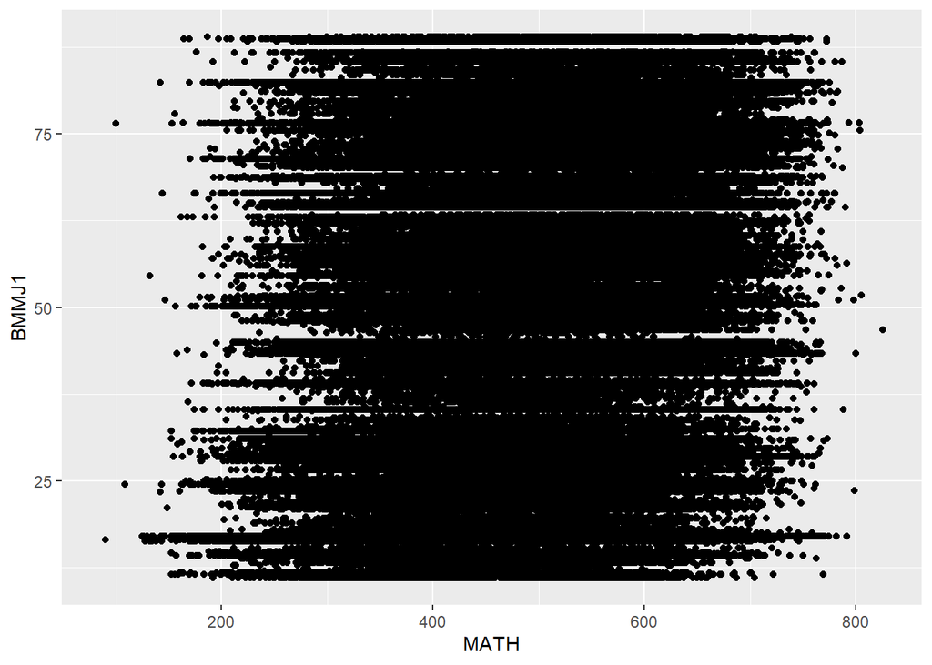

```r
# 1. Mean ISEI: 14.13% explained
# 2. Lowest ISEI: 12.35% explained
# 3. Highest ISEI: 11.63% explained
# 4. Mother's ISEI: 11.19% explained
# 5. Father's ISEI: 8.07% explained

# explained variance is highest if we use the mean occupation

# plot the relation between MATH and the occupation variables
ggplot(data_occupation, aes(x = MATH, y = BMMJ1)) + geom_point()
```

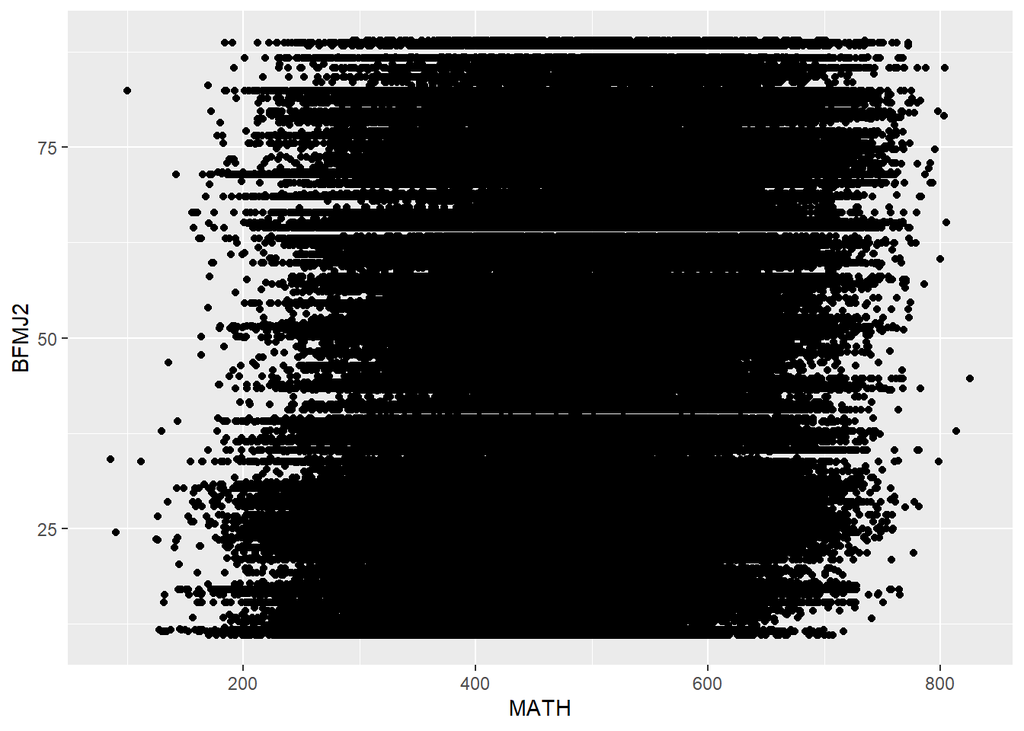

```r
ggplot(data_occupation, aes(x = MATH, y = BFMJ2)) + geom_point()
```

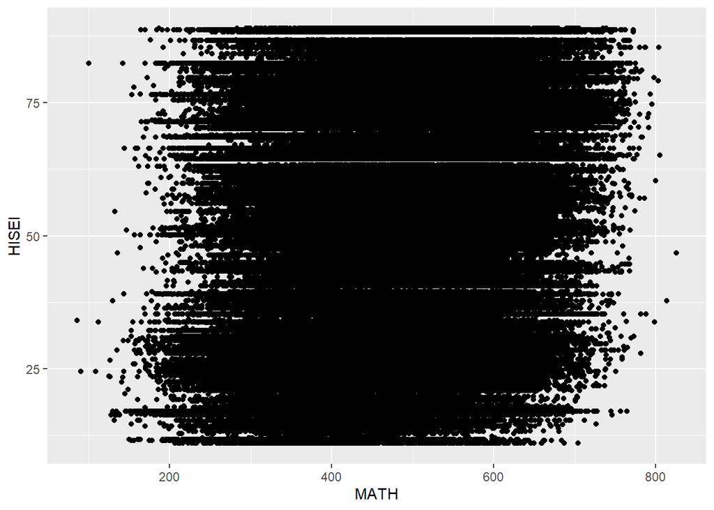

```r
ggplot(data_occupation, aes(x = MATH, y = HISEI)) + geom_point()
```

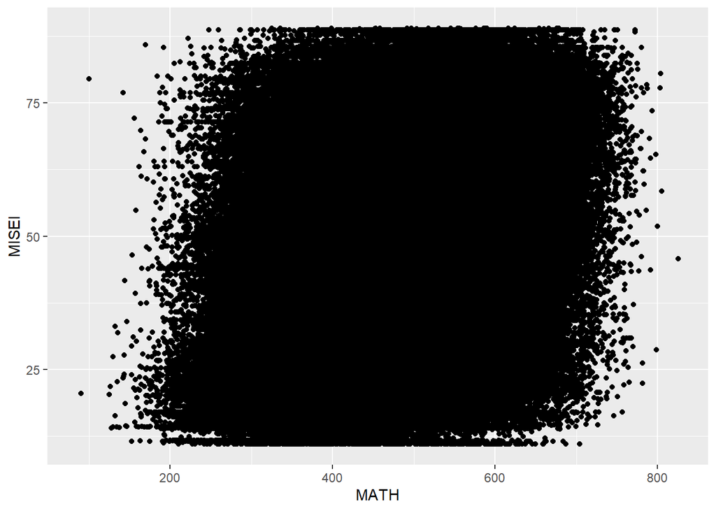

```r
ggplot(data_occupation, aes(x = MATH, y = MISEI)) + geom_point()
```

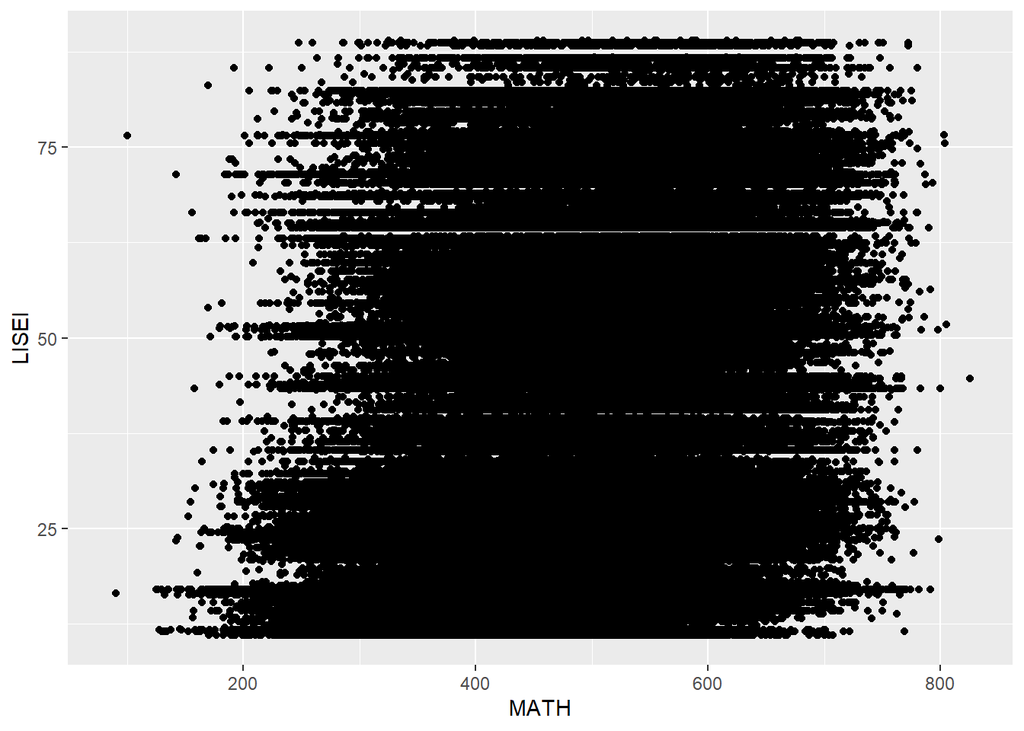

```r
ggplot(data_occupation, aes(x = MATH, y = LISEI)) + geom_point()
```

```r
# they look about linear, but hard to see with this many datapoints
```

#### Inspect education parents (misschien overbodig / te veel werk)

```r
#ST005Q01TA  # highest level of schooling completed by mother
#ST006Q01TA:ST006Q04TA # Does mother have this qualification?
#ST007Q01TA # highest level of schooling completed by father
#ST008Q01TA:ST008Q04TA # Does father have this qualification?

# inspect all together
summary(lm(data = data, MATH ~ ST005Q01TA + ST006Q01TA + ST006Q02TA + ST006Q03TA + ST006Q04TA + ST007Q01TA + ST008Q01TA + ST008Q02TA + ST008Q03TA + ST008Q04TA))
```

```
##
## Call:
## lm(formula = MATH ~ ST005Q01TA + ST006Q01TA + ST006Q02TA + ST006Q03TA +
##     ST006Q04TA + ST007Q01TA + ST008Q01TA + ST008Q02TA + ST008Q03TA +
##     ST008Q04TA, data = data)
##
## Residuals:
##     Min      1Q  Median      3Q     Max
## -360.92  -64.10   -1.87   62.55  360.13
##
## Coefficients:
##             Estimate Std. Error t value Pr(>|t|)
## (Intercept) 469.7873     1.4278 329.029  < 2e-16 ***
## ST005Q01TA  -14.9827     0.1835 -81.639  < 2e-16 ***
## ST006Q01TA   37.8896     0.6769  55.972  < 2e-16 ***
## ST006Q02TA  -27.7048     0.4235 -65.413  < 2e-16 ***
## ST006Q03TA   -4.6995     0.4171 -11.266  < 2e-16 ***
## ST006Q04TA    5.8915     0.4102  14.362  < 2e-16 ***
## ST007Q01TA  -13.4893     0.1860 -72.515  < 2e-16 ***
## ST008Q01TA   28.2809     0.6518  43.390  < 2e-16 ***
## ST008Q02TA  -22.9054     0.4342 -52.749  < 2e-16 ***
## ST008Q03TA    3.0818     0.4182   7.369 1.72e-13 ***
## ST008Q04TA    4.9870     0.4040  12.344  < 2e-16 ***
## ---
## Signif. codes:  0 '***' 0.001 '**' 0.01 '*' 0.05 '.' 0.1 ' ' 1
##
## Residual standard error: 90.39 on 333145 degrees of freedom
##   (278848 observations deleted due to missingness)
## Multiple R-squared:   0.15,  Adjusted R-squared:   0.15
## F-statistic:  5880 on 10 and 333145 DF,  p-value: < 2.2e-16
```

```r
# explains 15% of variance

# qualification mother
summary(lm(data = data, MATH ~ ST005Q01TA + ST006Q01TA + ST006Q02TA + ST006Q03TA + ST006Q04TA))
```

```
##
## Call:
## lm(formula = MATH ~ ST005Q01TA + ST006Q01TA + ST006Q02TA + ST006Q03TA +
##     ST006Q04TA, data = data)
##
## Residuals:
##     Min      1Q  Median      3Q     Max
## -353.35  -65.47   -1.92   63.75  369.78
##
## Coefficients:
##             Estimate Std. Error t value Pr(>|t|)
## (Intercept) 471.2043     1.2548  375.51   <2e-16 ***
## ST005Q01TA  -22.9780     0.1517 -151.52   <2e-16 ***
## ST006Q01TA   51.0971     0.5763   88.67   <2e-16 ***
## ST006Q02TA  -37.1066     0.3685 -100.68   <2e-16 ***
## ST006Q03TA   -4.3582     0.3611  -12.07   <2e-16 ***
## ST006Q04TA    7.9482     0.3414   23.28   <2e-16 ***
## ---
## Signif. codes:  0 '***' 0.001 '**' 0.01 '*' 0.05 '.' 0.1 ' ' 1
##
## Residual standard error: 92.02 on 365111 degrees of freedom
##   (246887 observations deleted due to missingness)
## Multiple R-squared:  0.1215, Adjusted R-squared:  0.1215
## F-statistic: 1.01e+04 on 5 and 365111 DF,  p-value: < 2.2e-16
```

```r
# explains 12.15% of variance

# only ISCED of mother
summary(lm(data = data, MATH ~ ST005Q01TA))
```

```
##
## Call:
## lm(formula = MATH ~ ST005Q01TA, data = data)
##
## Residuals:
##     Min      1Q  Median      3Q     Max
## -367.20  -67.02   -1.29   66.46  379.62
##
## Coefficients:
##             Estimate Std. Error t value Pr(>|t|)
## (Intercept) 510.0578     0.2413  2113.4   <2e-16 ***
## ST005Q01TA  -26.1155     0.1134  -230.3   <2e-16 ***
## ---
## Signif. codes:  0 '***' 0.001 '**' 0.01 '*' 0.05 '.' 0.1 ' ' 1
##
## Residual standard error: 94.28 on 581440 degrees of freedom
##   (30562 observations deleted due to missingness)
## Multiple R-squared:  0.08359,    Adjusted R-squared:  0.08359
## F-statistic: 5.304e+04 on 1 and 581440 DF,  p-value: < 2.2e-16
```

```r
# explains 8.36% of variance

# qualifications father
summary(lm(data = data, MATH ~ ST007Q01TA + ST008Q01TA + ST008Q02TA + ST008Q03TA + ST008Q04TA))
```

```
##
## Call:
## lm(formula = MATH ~ ST007Q01TA + ST008Q01TA + ST008Q02TA + ST008Q03TA +
##     ST008Q04TA, data = data)
##
## Residuals:
##     Min      1Q  Median      3Q     Max
## -378.00  -66.42   -1.31   65.38  359.78
##
## Coefficients:
##             Estimate Std. Error  t value Pr(>|t|)
## (Intercept) 483.2007     1.2257  394.209   <2e-16 ***
## ST007Q01TA  -22.6955     0.1588 -142.929   <2e-16 ***
## ST008Q01TA   43.6379     0.5789   75.375   <2e-16 ***
## ST008Q02TA  -36.5892     0.3936  -92.968   <2e-16 ***
## ST008Q03TA   -0.6400     0.3756   -1.704   0.0884 .
## ST008Q04TA    6.5978     0.3489   18.908   <2e-16 ***
## ---
## Signif. codes:  0 '***' 0.001 '**' 0.01 '*' 0.05 '.' 0.1 ' ' 1
##
## Residual standard error: 92.77 on 347626 degrees of freedom
##   (264372 observations deleted due to missingness)
## Multiple R-squared:  0.1097, Adjusted R-squared:  0.1097
## F-statistic:  8565 on 5 and 347626 DF,  p-value: < 2.2e-16
```

```r
# explains 10.97% of variance

# only ISCED of father
summary(lm(data = data, MATH ~ ST007Q01TA))
```

```
##
## Call:
## lm(formula = MATH ~ ST007Q01TA, data = data)
##
## Residuals:
##     Min      1Q  Median      3Q     Max
## -394.48  -67.78   -0.92   67.43  371.65
##
## Coefficients:
##             Estimate Std. Error t value Pr(>|t|)
## (Intercept) 510.4144     0.2500  2042.1   <2e-16 ***
## ST007Q01TA  -25.3095     0.1153  -219.6   <2e-16 ***
## ---
## Signif. codes:  0 '***' 0.001 '**' 0.01 '*' 0.05 '.' 0.1 ' ' 1
##
## Residual standard error: 94.65 on 570807 degrees of freedom
##   (41195 observations deleted due to missingness)
## Multiple R-squared:  0.07789,    Adjusted R-squared:  0.07789
## F-statistic: 4.822e+04 on 1 and 570807 DF,  p-value: < 2.2e-16
```

```r
# explains 7.79% of variance

# HISCED
summary(lm(data = data, MATH ~ HISCED))
```

```
##
## Call:
## lm(formula = MATH ~ HISCED, data = data)
##
## Residuals:
##     Min      1Q  Median      3Q     Max
## -397.47  -67.54   -0.49   67.73  367.59
##
## Coefficients:
##              Estimate Std. Error t value Pr(>|t|)
## (Intercept) 386.15973    0.40854   945.2   <2e-16 ***
## HISCED       16.18843    0.08328   194.4   <2e-16 ***
## ---
## Signif. codes:  0 '***' 0.001 '**' 0.01 '*' 0.05 '.' 0.1 ' ' 1
##
## Residual standard error: 95.58 on 588991 degrees of freedom
##   (23011 observations deleted due to missingness)
## Multiple R-squared:  0.06029,    Adjusted R-squared:  0.06028
## F-statistic: 3.779e+04 on 1 and 588991 DF,  p-value: < 2.2e-16
```

```r
# explains only 6.03% of variance

# why does HISCED only explain 6.03% when the ISCED of mother and father both explain more and there is much more information available?
```

#### Take max score beta and plot se for countries all taken together

The beta in the PISA results are equal to the betas for the max score of an item. Therefore we only inspect these beta values.

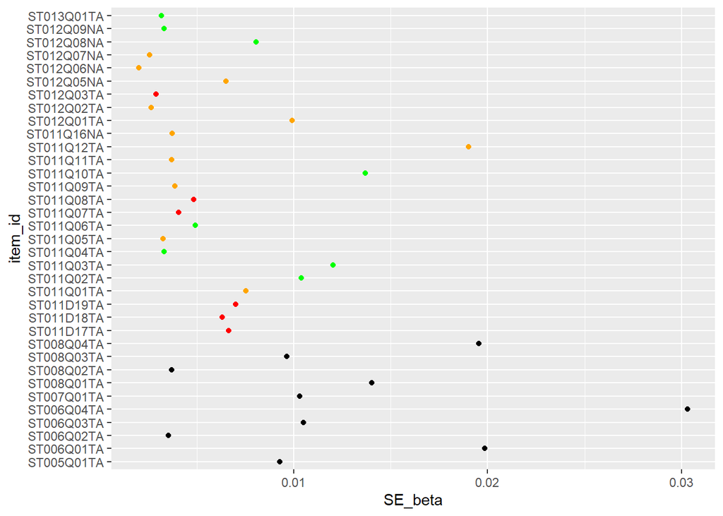

```r
# models cnt together = parms_1PL_2 and parms_2PL_2

# take the coefficients of the 2PL with all countries together
coef <- coef(parms_2PL_2)

# make a variable for max score per item
coef <- coef %>% group_by(item_id) %>% mutate(max_score=max(item_score))

# keep only the betas of the items where the item score is the max score
coef2 <- coef[coef$item_score == coef$max_score,]
coef2 <- coef2 %>%
  mutate(color = ifelse(item_id == "ST011Q07TA" | item_id == "ST011Q08TA" |
                          item_id == "ST012Q03TA" | item_id == "ST011D17TA" |
                          item_id == "ST011D18TA" | item_id == "ST011D19TA",
                          "red",
                        ifelse(item_id == "ST011Q01TA" | item_id == "ST011Q05TA" |
                                 item_id == "ST011Q09TA" | item_id == "ST011Q11TA" |
                                 item_id == "ST011Q12TA" | item_id == "ST011Q16NA" |
                                 item_id == "ST012Q01TA" | item_id == "ST012Q02TA" |
                                 item_id == "ST012Q05NA" | item_id == "ST012Q06NA" |
                                 item_id == "ST012Q07NA", "orange",
                               ifelse(item_id == "ST011Q02TA" | item_id == "ST011Q02TA" |
                                        item_id == "ST011Q03TA" | item_id == "ST011Q04TA" |
                                        item_id == "ST011Q06TA" | item_id == "ST011Q10TA" |
                                        item_id == "ST012Q04TA" | item_id == "ST012Q08NA" |
                                        item_id == "ST012Q09NA" | item_id == "ST013Q01TA",
                                      "green",
                                      "black"))))

# plot SEs
ggplot(coef2, aes(x=SE_beta, y=item_id, color = color)) + geom_point() +
  scale_color_identity()
```

#### Take max score beta and plot se for countries all seperatelty

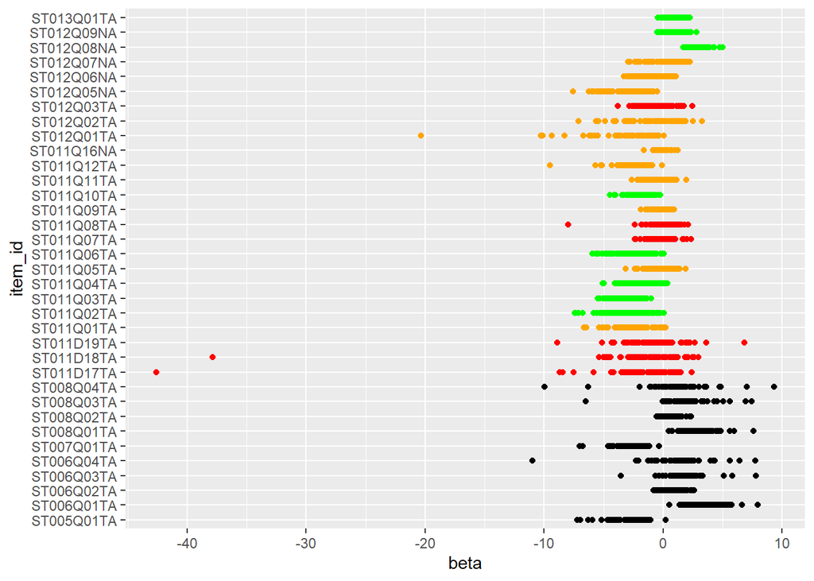

```r
# models cnt seperate = parms_1PL and parms_2PL

# take the coefficients of the 2PL with all countries together
coef <- coef(parms_2PL)

# split item_id into item and country (so we can plot per item)
coef$item_id <- strsplit(coef$item_id, '_')
coef$CNT <- sapply(coef$item_id, function(x) x[length(x)])
coef$item_id <- sapply(coef$item_id, function(x) x[1])


# make a variable for max score per item
coef <- coef %>% group_by(item_id) %>% mutate(max_score=max(item_score))

# keep only the betas of the items where the item score is the max score
coef2 <- coef[coef$item_score == coef$max_score,]

coef2 <- coef2 %>%
  mutate(color = ifelse(item_id == "ST011Q07TA" | item_id == "ST011Q08TA" |
                          item_id == "ST012Q03TA" | item_id == "ST011D17TA" |
                          item_id == "ST011D18TA" | item_id == "ST011D19TA",
                          "red",
                        ifelse(item_id == "ST011Q01TA" | item_id == "ST011Q05TA" |
                                 item_id == "ST011Q09TA" | item_id == "ST011Q11TA" |
                                 item_id == "ST011Q12TA" | item_id == "ST011Q16NA" |
                                 item_id == "ST012Q01TA" | item_id == "ST012Q02TA" |
                                 item_id == "ST012Q05NA" | item_id == "ST012Q06NA" |
                                 item_id == "ST012Q07NA", "orange",
                               ifelse(item_id == "ST011Q02TA" | item_id == "ST011Q02TA" |
                                        item_id == "ST011Q03TA" | item_id == "ST011Q04TA" |
                                        item_id == "ST011Q06TA" | item_id == "ST011Q10TA" |
                                        item_id == "ST012Q04TA" | item_id == "ST012Q08NA" |
                                        item_id == "ST012Q09NA" | item_id == "ST013Q01TA",
                                      "green",
                                      "black"))))

# plot betas
ggplot(coef2, aes(x=beta, y=item_id, color = color)) + geom_point() +
  scale_color_identity()
```

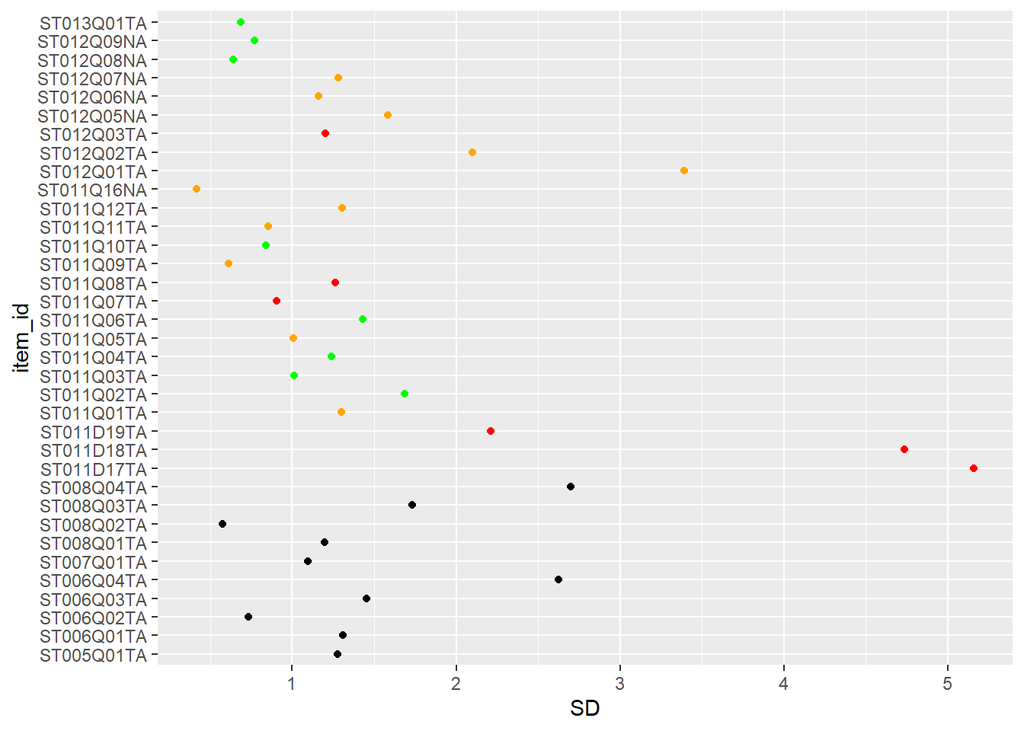

```r
# plot SD
coef2 <- coef2 %>% group_by(item_id) %>% mutate(SD = sd(beta))
ggplot(coef2, aes(x=SD, y=item_id, color = color)) + geom_point() +
  scale_color_identity()
```

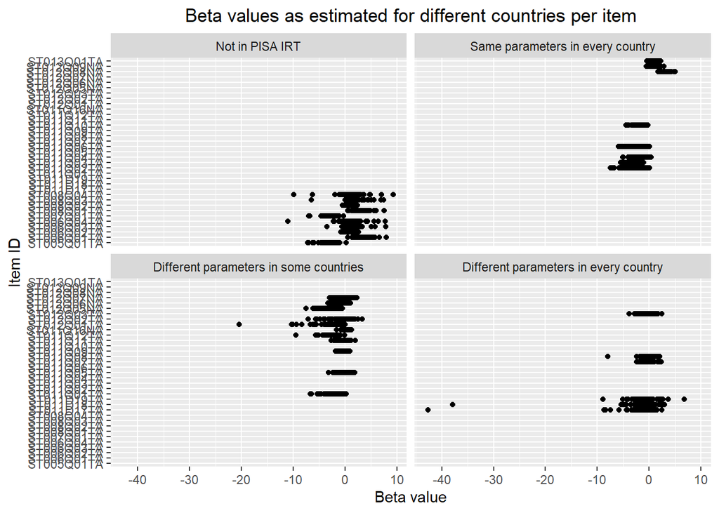

```r
# plot facet_wrap
plot_names <- c('black' = "Not in PISA IRT",
                'green' = "Same parameters in every country",
                'orange' = "Different parameters in some countries",
                'red' = "Different parameters in every country")
item_plot <- ggplot(coef2, aes(x=beta, y=item_id)) +
  geom_point() +
  facet_wrap(vars(color), labeller = as_labeller(plot_names)) +
  xlab("Beta value") +
  ylab("Item ID") +
  ggtitle("Beta values as estimated for different countries per item") +
  theme(plot.title = element_text(hjust = 0.5))
item_plot
```

```r
# ggsave(item_plot, filename = "IRT_item_plot.png", height = 12, width = 6)

# plot SE? No SE to plot
```

#### Investigate results of table

The large standard deviation might be the result of a coding mistake. First, we make sure that this is not the case by checking the distributions of the answers over categories. Second, we investigate the distributions per outlying country to check if there is something wrong with the measurement.

```r
# Some items have a very large standard deviation
# Are the answers categorical? How many categories?

# ST012Q01TA
invest_1201 <- responses %>% filter(startsWith(item_id, "ST012Q01TA"))
table(invest_1201$item_score) # looks alright
```

```
##
##      0      1      2      3
##   8272 120424 136106 120039
```

```r
# ST011D19TA
invest_1119 <- responses %>% filter(startsWith(item_id, "ST011D19TA"))
table(invest_1119$item_score) # looks alright
```

```
##
##      0      1
## 197794 307743
```

```r
# ST011D18TA
invest_1118 <- responses %>% filter(startsWith(item_id, "ST011D18TA"))
table(invest_1118$item_score) # looks alright
```

```
##
##      0      1
## 200909 348958
```

```r
# ST011D17TA
invest_1117 <- responses %>% filter(startsWith(item_id, "ST011D17TA"))
table(invest_1117$item_score) # looks alright
```

```
##
##      0      1
## 183217 379100
```

```r
# ST008Q04TA
invest_0804 <- responses %>% filter(startsWith(item_id, "ST008Q04TA"))
table(invest_0804$item_score) # looks alright
```

```
##
##      0      1
## 216438 109459
```

```r
# ST008Q03TA
invest_0803 <- responses %>% filter(startsWith(item_id, "ST008Q03TA"))
table(invest_0803$item_score) # looks alright
```

```
##
##      0      1
## 315403 132549
```

```r
# ST007Q01TA
invest_0701 <- responses %>% filter(startsWith(item_id, "ST007Q01TA"))
table(invest_0701$item_score) # one category missing
```

```
##
##      0      3      4
##  16928 218699 292188
```

```r
# ST006Q04TA
invest_0604 <- responses %>% filter(startsWith(item_id, "ST006Q04TA"))
table(invest_0604$item_score) # looks alright
```

```
##
##      0      1
## 220858 100059
```

```r
# All answer categories look reasonable and answers are distributed over all categories
# Sometimes a little scewed, but all categories have enough answers

# What countries are outliers? Let's look at the distribution within country

# ST012Q01TA has one visible outliers on the negative side
coef2 %>% filter(item_id == "ST012Q01TA") %>% arrange(desc(beta))
```

```
## # A tibble: 55 × 10
## # Groups:   item_id [1]
##    item_id alpha item_score    beta SE_alpha SE_beta CNT   max_score color    SD
##    <chr>   <dbl>      <int>   <dbl>    <dbl>   <dbl> <chr>     <int> <chr> <dbl>
##  1 ST012Q… 0.952          3  0.0428   0.0297  0.0257 PHL           3 oran…  3.39
##  2 ST012Q… 1.01           3 -0.341    0.0234  0.0233 IDN           3 oran…  3.39
##  3 ST012Q… 1.19           3 -0.465    0.0359  0.0229 PAN           3 oran…  3.39
##  4 ST012Q… 1.09           3 -0.536    0.0394  0.0462 VNM           3 oran…  3.39
##  5 ST012Q… 1.33           3 -0.571    0.0376  0.0241 PER           3 oran…  3.39
##  6 ST012Q… 0.734          3 -0.742    0.0280  0.0450 DOM           3 oran…  3.39
##  7 ST012Q… 0.785          3 -0.854    0.0315  0.0543 GEO           3 oran…  3.39
##  8 ST012Q… 0.578          3 -0.923    0.0254  0.0727 MYS           3 oran…  3.39
##  9 ST012Q… 0.615          3 -0.933    0.0267  0.0585 MDA           3 oran…  3.39
## 10 ST012Q… 0.454          3 -0.940    0.0243  0.0907 HKG           3 oran…  3.39
## # ℹ 45 more rows
```

```r
table(responses[responses$item_id == "ST012Q01TA_SWE",]$item_score)
```

```
##
##    0    1    2    3
##   63  795 1693 2800
```

```r
# ST011D19TA has one visible outlier on the negative side and one on the positive side
coef2 %>% filter(item_id == "ST011D19TA") %>% arrange(desc(beta))
```

```
## # A tibble: 66 × 10
## # Groups:   item_id [1]
##    item_id   alpha item_score  beta SE_alpha SE_beta CNT   max_score color    SD
##    <chr>     <dbl>      <int> <dbl>    <dbl>   <dbl> <chr>     <int> <chr> <dbl>
##  1 ST011D19… 0.210          1  6.81   0.0400  1.29   LVA           1 red    2.21
##  2 ST011D19… 0.338          1  3.63   0.0246  0.260  AUS           1 red    2.21
##  3 ST011D19… 0.896          1  2.66   0.0607  0.150  GEO           1 red    2.21
##  4 ST011D19… 0.888          1  2.23   0.0430  0.0933 CRI           1 red    2.21
##  5 ST011D19… 0.192          1  2.18   0.0292  0.351  FRA           1 red    2.21
##  6 ST011D19… 0.881          1  2.05   0.0305  0.0622 GBR           1 red    2.21
##  7 ST011D19… 0.766          1  1.99   0.0424  0.101  NZL           1 red    2.21
##  8 ST011D19… 0.371          1  1.89   0.0302  0.161  AUT           1 red    2.21
##  9 ST011D19… 0.592          1  1.59   0.0369  0.101  JPN           1 red    2.21
## 10 ST011D19… 1.07           1  1.50   0.0503  0.0615 NOR           1 red    2.21
## # ℹ 56 more rows
```

```r
table(responses[responses$item_id == "ST011D19TA_IRL",]$item_score)
```

```
##
##    0    1
##   76 5447
```

```r
table(responses[responses$item_id == "ST011D19TA_LVA",]$item_score)
```

```
##
##    0    1
## 4166 1010
```

```r
# ST011D18TA has one visible outlier on the negative side
coef2 %>% filter(item_id == "ST011D18TA") %>% arrange(desc(beta)) %>% select(CNT)
```

```
## # A tibble: 74 × 2
## # Groups:   item_id [1]
##    item_id    CNT
##    <chr>      <chr>
##  1 ST011D18TA NZL
##  2 ST011D18TA THA
##  3 ST011D18TA JPN
##  4 ST011D18TA GEO
##  5 ST011D18TA SWE
##  6 ST011D18TA MLT
##  7 ST011D18TA AUS
##  8 ST011D18TA SGP
##  9 ST011D18TA PAN
## 10 ST011D18TA QRT
## # ℹ 64 more rows
```

```r
table(responses[responses$item_id == "ST011D18TA_DNK",]$item_score)
```

```
##
##    0    1
##  360 7093
```

```r
# again skewed

# ST011D17TA has one visible outlier on the negative side
coef2 %>% filter(item_id == "ST011D17TA") %>% arrange(desc(beta))
```

```
## # A tibble: 76 × 10
## # Groups:   item_id [1]
##    item_id   alpha item_score  beta SE_alpha SE_beta CNT   max_score color    SD
##    <chr>     <dbl>      <int> <dbl>    <dbl>   <dbl> <chr>     <int> <chr> <dbl>
##  1 ST011D17… 0.715          1 2.40    0.0591  0.180  MLT           1 red    5.16
##  2 ST011D17… 0.376          1 1.46    0.0220  0.0949 AUS           1 red    5.16
##  3 ST011D17… 1.35           1 1.26    0.0582  0.0450 JPN           1 red    5.16
##  4 ST011D17… 0.762          1 1.17    0.0430  0.0681 GEO           1 red    5.16
##  5 ST011D17… 1.30           1 0.988   0.0574  0.0426 NLD           1 red    5.16
##  6 ST011D17… 0.676          1 0.976   0.0305  0.0537 CHL           1 red    5.16
##  7 ST011D17… 1.55           1 0.741   0.0520  0.0282 PER           1 red    5.16
##  8 ST011D17… 0.588          1 0.692   0.0348  0.0616 ISR           1 red    5.16
##  9 ST011D17… 1.12           1 0.551   0.0469  0.0354 SWE           1 red    5.16
## 10 ST011D17… 1.30           1 0.490   0.0598  0.0367 MAC           1 red    5.16
## # ℹ 66 more rows
```

```r
table(responses[responses$item_id == "ST011D17TA_SVN",]$item_score)
```

```
##
##    0    1
## 1288 5013
```

```r
# again skewed

# ST011Q08TA has one visible outlier on the negative side
coef2 %>% filter(item_id == "ST011Q08TA") %>% arrange(desc(beta))
```

```
## # A tibble: 80 × 10
## # Groups:   item_id [1]
##    item_id   alpha item_score  beta SE_alpha SE_beta CNT   max_score color    SD
##    <chr>     <dbl>      <int> <dbl>    <dbl>   <dbl> <chr>     <int> <chr> <dbl>
##  1 ST011Q08… 0.693          1  2.07   0.0390  0.109  MAR           1 red    1.26
##  2 ST011Q08… 0.321          1  1.79   0.0213  0.129  IDN           1 red    1.26
##  3 ST011Q08… 0.655          1  1.77   0.0336  0.0890 CRI           1 red    1.26
##  4 ST011Q08… 0.500          1  1.54   0.0266  0.0881 THA           1 red    1.26
##  5 ST011Q08… 0.380          1  1.53   0.0293  0.131  MEX           1 red    1.26
##  6 ST011Q08… 0.587          1  1.49   0.0338  0.0892 BRN           1 red    1.26
##  7 ST011Q08… 1.44           1  1.33   0.0655  0.0488 NLD           1 red    1.26
##  8 ST011Q08… 1.55           1  1.31   0.0679  0.0431 JPN           1 red    1.26
##  9 ST011Q08… 0.355          1  1.17   0.0230  0.0926 BRA           1 red    1.26
## 10 ST011Q08… 0.738          1  1.08   0.0386  0.0629 SAU           1 red    1.26
## # ℹ 70 more rows
```

```r
table(responses[responses$item_id == "ST011Q08TA_PER",]$item_score)
```

```
##
##    0    1
## 2160 3829
```

```r
# ST011Q12TA has one visible outlier on the negative side
coef2 %>% filter(item_id == "ST011Q12TA") %>% arrange(desc(beta))
```

```
## # A tibble: 80 × 10
## # Groups:   item_id [1]
##    item_id  alpha item_score   beta SE_alpha SE_beta CNT   max_score color    SD
##    <chr>    <dbl>      <int>  <dbl>    <dbl>   <dbl> <chr>     <int> <chr> <dbl>
##  1 ST011Q1… 1.08           1 -0.123   0.0433  0.0308 SAU           1 oran…  1.31
##  2 ST011Q1… 1.35           1 -0.901   0.0558  0.0367 SWE           1 oran…  1.31
##  3 ST011Q1… 1.24           1 -0.948   0.0507  0.0399 VNM           1 oran…  1.31
##  4 ST011Q1… 1.17           1 -0.994   0.0331  0.0277 QAT           1 oran…  1.31
##  5 ST011Q1… 1.66           1 -1.03    0.0667  0.0342 FIN           1 oran…  1.31
##  6 ST011Q1… 0.953          1 -1.08    0.0379  0.0465 MAR           1 oran…  1.31
##  7 ST011Q1… 2.04           1 -1.23    0.0881  0.0375 BGR           1 oran…  1.31
##  8 ST011Q1… 1.07           1 -1.28    0.0437  0.0494 ALB           1 oran…  1.31
##  9 ST011Q1… 1.52           1 -1.32    0.0650  0.0435 NOR           1 oran…  1.31
## 10 ST011Q1… 1.05           1 -1.32    0.0505  0.0589 USA           1 oran…  1.31
## # ℹ 70 more rows
```

```r
table(responses[responses$item_id == "ST011Q12TA_MEX",]$item_score)
```

```
##
##    0    1
##  172 6269
```

```r
# again skewed

# ST008Q04TA has two visible outliers on the negative side and two on the positive side
coef2 %>% filter(item_id == "ST008Q04TA") %>% arrange(desc(beta))
```

```
## # A tibble: 54 × 10
## # Groups:   item_id [1]
##    item_id   alpha item_score  beta SE_alpha SE_beta CNT   max_score color    SD
##    <chr>     <dbl>      <int> <dbl>    <dbl>   <dbl> <chr>     <int> <chr> <dbl>
##  1 ST008Q04… 0.171          1  9.31   0.0444   2.41  CHE           1 black  2.70
##  2 ST008Q04… 0.465          1  7.03   0.0766   1.10  AUT           1 black  2.70
##  3 ST008Q04… 0.216          1  4.82   0.0398   0.893 USA           1 black  2.70
##  4 ST008Q04… 0.232          1  4.77   0.0379   0.781 HUN           1 black  2.70
##  5 ST008Q04… 0.316          1  4.71   0.0394   0.575 CZE           1 black  2.70
##  6 ST008Q04… 0.615          1  3.61   0.0555   0.299 PRT           1 black  2.70
##  7 ST008Q04… 0.446          1  3.48   0.0403   0.308 MAR           1 black  2.70
##  8 ST008Q04… 0.457          1  3.01   0.0315   0.204 THA           1 black  2.70
##  9 ST008Q04… 1.08           1  2.62   0.0695   0.133 VNM           1 black  2.70
## 10 ST008Q04… 0.309          1  2.62   0.0392   0.341 URY           1 black  2.70
## # ℹ 44 more rows
```

```r
table(responses[responses$item_id == "ST008Q04TA_CHE",]$item_score)
```

```
##
##    0    1
## 3891  801
```

```r
table(responses[responses$item_id == "ST008Q04TA_AUT",]$item_score)
```

```
##
##    0    1
## 5472  229
```

```r
table(responses[responses$item_id == "ST008Q04TA_AUS",]$item_score)
```

```
##
##    0    1
## 7291 2881
```

```r
table(responses[responses$item_id == "ST008Q04TA_JPN",]$item_score)
```

```
##
##    0    1
## 3537 1132
```

```r
# ST008Q03TA has one visible outlier on the negative side
coef2 %>% filter(item_id == "ST008Q03TA") %>% arrange(desc(beta))
```

```
## # A tibble: 70 × 10
## # Groups:   item_id [1]
##    item_id   alpha item_score  beta SE_alpha SE_beta CNT   max_score color    SD
##    <chr>     <dbl>      <int> <dbl>    <dbl>   <dbl> <chr>     <int> <chr> <dbl>
##  1 ST008Q03… 0.215          1  7.42   0.0308   1.05  AUS           1 black  1.73
##  2 ST008Q03… 0.328          1  6.92   0.0389   0.797 ITA           1 black  1.73
##  3 ST008Q03… 0.212          1  5.58   0.0383   1.01  GRC           1 black  1.73
##  4 ST008Q03… 0.433          1  5.04   0.0512   0.576 KOR           1 black  1.73
##  5 ST008Q03… 0.168          1  4.55   0.0319   0.869 AUT           1 black  1.73
##  6 ST008Q03… 0.477          1  4.29   0.0515   0.441 HUN           1 black  1.73
##  7 ST008Q03… 0.380          1  3.74   0.0292   0.274 ARG           1 black  1.73
##  8 ST008Q03… 0.214          1  3.43   0.0333   0.538 FRA           1 black  1.73
##  9 ST008Q03… 0.584          1  3.22   0.0496   0.255 PRT           1 black  1.73
## 10 ST008Q03… 0.370          1  2.73   0.0428   0.318 MDA           1 black  1.73
## # ℹ 60 more rows
```

```r
table(responses[responses$item_id == "ST008Q03TA_FIN",]$item_score)
```

```
##
##    0    1
## 2857 1523
```

```r
# ST007Q01TA has two visible outliers on the negative side
coef2 %>% filter(item_id == "ST007Q01TA") %>% arrange(desc(beta))
```

```
## # A tibble: 74 × 10
## # Groups:   item_id [1]
##    item_id  alpha item_score   beta SE_alpha SE_beta CNT   max_score color    SD
##    <chr>    <dbl>      <int>  <dbl>    <dbl>   <dbl> <chr>     <int> <chr> <dbl>
##  1 ST007Q0… 0.334          4 -0.337   0.0116  0.0282 MAR           4 black  1.10
##  2 ST007Q0… 0.943          4 -1.18    0.0444  0.0347 DEU           4 black  1.10
##  3 ST007Q0… 0.307          4 -1.26    0.0133  0.0498 COL           4 black  1.10
##  4 ST007Q0… 0.296          4 -1.38    0.0103  0.0429 BRA           4 black  1.10
##  5 ST007Q0… 0.437          4 -1.53    0.0200  0.0505 SAU           4 black  1.10
##  6 ST007Q0… 0.312          4 -1.65    0.0166  0.0726 VNM           4 black  1.10
##  7 ST007Q0… 0.310          4 -1.66    0.0170  0.0744 PRT           4 black  1.10
##  8 ST007Q0… 0.750          4 -1.70    0.0386  0.0526 NLD           4 black  1.10
##  9 ST007Q0… 1.04           4 -1.72    0.0403  0.0427 AUT           4 black  1.10
## 10 ST007Q0… 0.719          4 -1.76    0.0317  0.0474 FRA           4 black  1.10
## # ℹ 64 more rows
```

```r
table(responses[responses$item_id == "ST007Q01TA_LVA",]$item_score) # one category missing
```

```
##
##    0    3    4
##   25 2358 2568
```

```r
table(responses[responses$item_id == "ST007Q01TA_GEO",]$item_score) # one category missing
```

```
##
##    0    3    4
##   38 1543 3791
```

```r
# ST006Q04TA has one visible outlier on the negative side
coef2 %>% filter(item_id == "ST006Q04TA") %>% arrange(desc(beta))
```

```
## # A tibble: 51 × 10
## # Groups:   item_id [1]
##    item_id   alpha item_score  beta SE_alpha SE_beta CNT   max_score color    SD
##    <chr>     <dbl>      <int> <dbl>    <dbl>   <dbl> <chr>     <int> <chr> <dbl>
##  1 ST006Q04… 0.226          1  7.75   0.0411   1.39  AUT           1 black  2.63
##  2 ST006Q04… 0.182          1  6.43   0.0384   1.35  CHE           1 black  2.63
##  3 ST006Q04… 0.429          1  5.62   0.0576   0.722 PRT           1 black  2.63
##  4 ST006Q04… 0.403          1  4.34   0.0424   0.439 CZE           1 black  2.63
##  5 ST006Q04… 0.395          1  4.24   0.0405   0.423 MAR           1 black  2.63
##  6 ST006Q04… 0.213          1  3.98   0.0331   0.622 SVN           1 black  2.63
##  7 ST006Q04… 0.484          1  3.00   0.0321   0.194 THA           1 black  2.63
##  8 ST006Q04… 0.339          1  2.97   0.0471   0.425 MKD           1 black  2.63
##  9 ST006Q04… 0.247          1  2.93   0.0185   0.226 CAN           1 black  2.63
## 10 ST006Q04… 0.431          1  2.60   0.0335   0.202 CHL           1 black  2.63
## # ℹ 41 more rows
```

```r
table(responses[responses$item_id == "ST006Q04TA_AUS",]$item_score)
```

```
##
##    0    1
## 8290 2033
```

```r
# ST006Q03TA has one visible outlier on the negative side and one on the positive side
coef2 %>% filter(item_id == "ST006Q03TA") %>% arrange(desc(beta))
```

```
## # A tibble: 70 × 10
## # Groups:   item_id [1]
##    item_id   alpha item_score  beta SE_alpha SE_beta CNT   max_score color    SD
##    <chr>     <dbl>      <int> <dbl>    <dbl>   <dbl> <chr>     <int> <chr> <dbl>
##  1 ST006Q03… 0.283          1  7.80   0.0372  1.00   ITA           1 black  1.46
##  2 ST006Q03… 0.281          1  5.80   0.0508  1.02   DEU           1 black  1.46
##  3 ST006Q03… 0.397          1  5.10   0.0502  0.624  HUN           1 black  1.46
##  4 ST006Q03… 0.424          1  5.07   0.0503  0.583  KOR           1 black  1.46
##  5 ST006Q03… 0.538          1  3.32   0.0471  0.273  PRT           1 black  1.46
##  6 ST006Q03… 0.350          1  3.21   0.0263  0.235  ARG           1 black  1.46
##  7 ST006Q03… 0.330          1  3.08   0.0420  0.395  MDA           1 black  1.46
##  8 ST006Q03… 0.390          1  2.81   0.0523  0.376  ISL           1 black  1.46
##  9 ST006Q03… 1.16           1  2.76   0.0533  0.0987 IDN           1 black  1.46
## 10 ST006Q03… 0.205          1  2.70   0.0346  0.472  JPN           1 black  1.46
## # ℹ 60 more rows
```

```r
table(responses[responses$item_id == "ST006Q03TA_ITA",]$item_score)
```

```
##
##    0    1
## 9377 1064
```

```r
table(responses[responses$item_id == "ST006Q03TA_FIN",]$item_score)
```

```
##
##    0    1
## 2962 1502
```

```r
# Most distributions are skewed, but no categories are missing / have almost no answers
# Except for on ST007Q01TA
# It does not look like a bad measurement
```

#### ST012Q01TA in dept

ST012Q01TA asks how many televisions there are in the pupil’s home. In PISA, this item has the same parameter for most countries, but a separate for some countries. In PISA these countries are the United Arab Emirates/Dubai (Arabic), Argentina (Spanish), Chile (Spanish), Hong Kong (China) (English), Hong Kong (China) (Chinese), Korea (Korean), Qatar (Arabic) and the United States (English). However, when we investigate the betas of our IRT analysis, these countries are not the outliers. Instead, Sweden is the clear outlier. Other countries on the edge of the distribution are Croatia, Poland, Japan and Estonia. Remarkebly, these countries are mostly located in Europe, while the countries seperated by PISA are all in North- and South America and Asia.

#### ST011D18TA in dept

ST011D18TA asks if a pupil has “country specific wealth item 2”. In PISA, this item has different parameters in every country. However, the betas in our IRT analysis suggests that the countries could use (about) the same parameter. However, there is one outlier, namely Denmark. This suggests that the second country specific wealth item of this country might not be comparable to the second country specific wealth items of other countries and might therefore be poorly chosen.

#### ST011D17TA in dept

ST011D17TA asks if a pupil has “country specific wealth item 1”. In PISA, this item has different parameters in every country. However, the betas in our IRT analysis suggests that the countries could use (about) the same parameter. However, there is one outlier, namely Slovenia. This suggests that the first country specific wealth item of Slovenia might not be comparable to the first country specific wealth items of other countries and might therefore be poorly chosen.

#### ST011Q08TA in dept

ST011Q08TA asks if a pupil has books of poetry in their home. In PISA, this item has different parameters in every country. However, the betas in our IRT analysis suggests that the countries could use (about) the same parameter. However, there is one outlier, namely Peru.

#### ST011Q12TA in dept

ST011Q12TA asks if a pupil has a dictionary in their home. In PISA, this item has different parameters in some countries. In PISA, these countries are Qatar (Arabic) and Saudi Arabia (Arabic, English). However, when we investigate the betas of our IRT analysis, these countries are not the outliers. Instead, Mexico is the clear outlier.

#### ST008Q04TA in dept x

ST008Q04TA asks if the father of the pupil has a ISCED level 4 training. In PISA, this item is not included in an IRT analysis, but only in the PCA model in the calculation of the HISCED indicator. The betas of our IRT analysis suggest that Switserland, Austria, Australia and Japan are outliers.

#### ST008Q03TA in dept

ST008Q03TA asks if the father of the pupil has a ISCED level 5 training. In PISA, this item is not included in an IRT analysis, but only in the PCA model in the calculation of the HISCED indicator. The betas of our IRT analysis suggest that Finland is an outlier.

#### ST007Q01TA in dept

ST007Q01TA asks what the highest level of schooling completed by the father of the pupil is. In PISA, this item is not included in an IRT analysis, but only in the PCA model in the calculation of the HISCED indicator. The betas of our IRT analysis suggest that Latvia and Georgia are outliers. Both have a notable distribution: Two categories (ISCED level 3B, 3C and ISCED level 2) have no answers.

#### ST006Q04TA in dept

ST006Q04TA asks if the mother of the pupil has a ISCED level 4 training. In PISA, this item is not included in an IRT analysis, but only in the PCA model in the calculation of the HISCED indicator. The betas of our IRT analysis suggest that Australia is an outlier. Note that Australia is also an outlier on ST008Q04TA (ISCED level 4 training father).

#### ST006Q03TA in dept

ST006Q03TA asks if the mother of the pupil has a ISCED level 5B training. In PISA, this item is not included in an IRT analysis, but only in the PCA model in the calculation of the HISCED indicator. The betas of our IRT analysis suggest that Italy and Finland are outliers.

#### Advise?

There seems little to no support for the seperate estimation of parameters that currently are estimated separately by PISA. The advise for PISA would be to reevaluate which countries have separately estimated parameters.

#### Adding HISEI into the IRT?

So can we using this scale make the ISEI variables of the mother and the father into seven categories? And can we than include it in the IRT analysis?

```r
# data$OCOD1 # ISCO-08 occupational code mother
# data$OCOD2 # ISCO-08 occupational code father

# make into characters
data$OCOD1 <- as.character(data$OCOD1)
data$OCOD2 <- as.character(data$OCOD2)

# recode values into categories
data$OCOD1_r <- ifelse(startsWith(data$OCOD1, '0'), '0',
                      ifelse(startsWith(data$OCOD1, '1'), '0',
                      ifelse(startsWith(data$OCOD1, '2'), '1',
                      ifelse(startsWith(data$OCOD1, '3'), '2',
                      ifelse(startsWith(data$OCOD1, '4'), '3',
                      ifelse(startsWith(data$OCOD1, '5'), '4',
                      ifelse(startsWith(data$OCOD1, '6'), '5',
                      ifelse(startsWith(data$OCOD1, '7'), '6',
                      ifelse(startsWith(data$OCOD1, '8'), '6',
                      ifelse(startsWith(data$OCOD1, '9'), '6',
                             NA))))))))))
data$OCOD1_r <- as.numeric(data$OCOD1_r)

data$OCOD2_r <- ifelse(startsWith(data$OCOD2, '0'), '0',
                      ifelse(startsWith(data$OCOD2, '1'), '0',
                      ifelse(startsWith(data$OCOD2, '2'), '1',
                      ifelse(startsWith(data$OCOD2, '3'), '2',
                      ifelse(startsWith(data$OCOD2, '4'), '3',
                      ifelse(startsWith(data$OCOD2, '5'), '4',
                      ifelse(startsWith(data$OCOD2, '6'), '5',
                      ifelse(startsWith(data$OCOD2, '7'), '6',
                      ifelse(startsWith(data$OCOD2, '8'), '6',
                      ifelse(startsWith(data$OCOD2, '9'), '6',
                             NA))))))))))
data$OCOD2_r <- as.numeric(data$OCOD2_r)

# add to the data
ESCS_items <- data.frame(ESCS_items, OCOD1_r = data$OCOD1_r, OCOD2_r = data$OCOD2_r)

# make long format dataset
ESCS_items_long <- ESCS_items %>% pivot_longer(cols = ST005Q01TA:OCOD2_r,
                                               names_to = "item",
                                                    values_to = "item_score")

# create variable item_id
ESCS_items_long$item_id <- ESCS_items_long$item

# change name to person_id
colnames(ESCS_items_long)[colnames(ESCS_items_long) == 'CNTSTUID'] <- 'person_id'

# give all the CS variables an unique item_id per country
items_CS <- ESCS_items %>% select(ST005Q01TA:OCOD2_r) %>% colnames()
for(var in items_CS){
  ESCS_items_long$item_id[ESCS_items_long$item_id == var] <- paste(
                                    ESCS_items_long$item[ESCS_items_long$item_id == var],
                                    ESCS_items_long$CNT[ESCS_items_long$item_id == var],
                                    sep = "_")
}

# drop the items where a score is missing
ESCS_items_long_complete <- ESCS_items_long %>% drop_na(item_score)

responses <- ESCS_items_long_complete %>% dplyr::select(person_id, item_id, item_score)

# remove items that either have only value 0 or do not have value 0
`%notin%` <- Negate(`%in%`)
baddies <- c("ST006Q03TA_POL", "ST008Q03TA_POL", "ST005Q01TA_CAN", "ST005Q01TA_JPN", "ST005Q01TA_POL", "ST007Q01TA_CAN", "ST007Q01TA_JPN","ST007Q01TA_POL")
responses <- responses %>%
  filter(item_id %notin% baddies)

# remove items with an alpha between -0.1 and 0.1
baddies2 <- c("ST011Q08TA_PAN", "ST006Q04TA_KAZ", "ST008Q04TA_NZL", "ST011D17TA_SVN", "ST007Q01TA_KSV", "ST012Q01TA_FRA", "ST012Q01TA_LUX", "ST012Q01TA_SVN", "ST008Q04TA_QAZ", "ST012Q01TA_NZL", "ST006Q04TA_POL", "ST008Q04TA_QRT", "ST006Q04TA_RUS", "ST008Q04TA_DEU", "ST012Q01TA_AUS", "ST011D18TA_AUT", "ST012Q01TA_TAP", "ST012Q01TA_IRL", "ST008Q04TA_ROU", "ST008Q03TA_DNK", "ST012Q01TA_HUN", "ST006Q04TA_NZL", "ST006Q04TA_FIN", "ST006Q04TA_ROU", "ST008Q04TA_KAZ", "ST012Q01TA_GBR", "ST012Q01TA_DNK", "ST012Q01TA_BEL", "ST008Q03TA_JPN", "ST008Q04TA_QMR", "ST006Q03TA_UKR", "ST008Q04TA_RUS", "ST012Q01TA_ISL", "ST012Q01TA_MLT", "ST006Q04TA_DEU", "ST006Q04TA_QRT", "ST012Q01TA_NLD", "ST008Q03TA_UKR", "ST008Q04TA_ISL", "ST012Q01TA_ESP", "ST012Q01TA_SWE", "ST011D19TA_LUX", "ST012Q01TA_USA", "ST011Q08TA_PER", "OCOD2_r_ARE", "ST008Q04TA_POL", "OCOD2_r_QAT", "ST006Q04TA_QAZ", "ST012Q01TA_KOR", "ST012Q01TA_DEU", "ST012Q02TA_JPN", "ST012Q01TA_CAN", "ST008Q03TA_HRV", "ST012Q01TA_ITA", "ST008Q03TA_BLR", "ST012Q01TA_FIN", "ST012Q01TA_ISR", "ST012Q01TA_POL", "ST012Q01TA_AUT", "ST008Q04TA_NOR")
responses <- responses %>%
  filter(item_id %notin% baddies2)

# estimate the parameters
parms_2PL <- dexterMML::fit_2pl(responses)
```

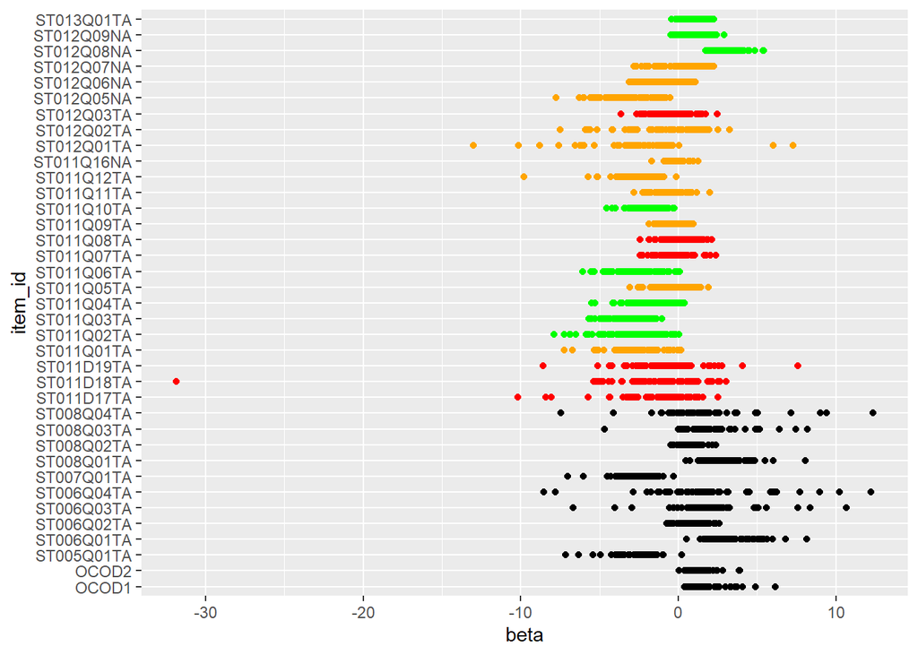

```r
coef <- coef(parms_2PL)

#write.csv(coef, "inspect_alpha2.csv")

# split item_id into item and country (so we can plot per item)
coef$item_id <- strsplit(coef$item_id, '_')
coef$CNT <- sapply(coef$item_id, function(x) x[length(x)])
coef$item_id <- sapply(coef$item_id, function(x) x[1])

# make a variable for max score per item
coef <- coef %>% group_by(item_id) %>% mutate(max_score=max(item_score))

# keep only the betas of the items where the item score is the max score
coef2 <- coef[coef$item_score == coef$max_score,]

coef2 <- coef2 %>%
  mutate(color = ifelse(item_id == "ST011Q07TA" | item_id == "ST011Q08TA" |
                          item_id == "ST012Q03TA" | item_id == "ST011D17TA" |
                          item_id == "ST011D18TA" | item_id == "ST011D19TA",
                          "red",
                        ifelse(item_id == "ST011Q01TA" | item_id == "ST011Q05TA" |
                                 item_id == "ST011Q09TA" | item_id == "ST011Q11TA" |
                                 item_id == "ST011Q12TA" | item_id == "ST011Q16NA" |
                                 item_id == "ST012Q01TA" | item_id == "ST012Q02TA" |
                                 item_id == "ST012Q05NA" | item_id == "ST012Q06NA" |
                                 item_id == "ST012Q07NA", "orange",
                               ifelse(item_id == "ST011Q02TA" | item_id == "ST011Q02TA" |
                                        item_id == "ST011Q03TA" | item_id == "ST011Q04TA" |
                                        item_id == "ST011Q06TA" | item_id == "ST011Q10TA" |
                                        item_id == "ST012Q04TA" | item_id == "ST012Q08NA" |
                                        item_id == "ST012Q09NA" | item_id == "ST013Q01TA",
                                      "green",
                                      "black"))))

# plot betas
ggplot(coef2, aes(x=beta, y=item_id, color = color)) + geom_point() +
  scale_color_identity()
```